# Google Trend no R

Fellipe

12 de dezembro de 2017

# Google Trends

O [Google Trends](https://trends.google.com.br/) é uma ferramenta gratuíta, muito poderosa e que pode ser implementada para ajudar em nossas estratégias de análises.

Através dele temos acesso a uma gigantesca base de dados que reúne os temas mais pesquisados na plataforma da google possibilitando acessar dados de busca desde o ano de 2004.

Através de suas séries temporais podemos avaliar a presença de padões, obter noções de tendência, sazonalidade e até mesmo arriscar algumas previsões.

Mas hoje o assunto não é séries temporais, hoje quero trazer aqui como podemos utilIzar sua API de dados diretamente de dentro do R.

# Google Trends no R

Para obtermos o acesso à base de dados da google, primeiro precisamos instalar o pacote `gtrends`, podemos utilizar o comando para baixar diretamente do [CRAN](https://cran.r-project.org/web/packages/gtrendsR/), ou pelo link do [github](https://github.com/PMassicotte/gtrendsR).

```r
#Ou, instalando direto do CRAN:
install.packages("gtrendsR")

#Obtendo o pacote do github:
install.packages("devtools")
devtools::install_github('PMassicotte/gtrendsR', ref = 'new-api')
```

Este pacote funciona como uma interface para obter e exibir as informações coletadas pelo Google Trends, além de retonar a representação geográfica das corrências pesquisadas. No CRAN existe o [manual do pacote](https://cran.r-project.org/web/packages/gtrendsR/gtrendsR.pdf) contedo maiores informações sobre o uso do pacote.

Com o pacote instalado ja podemos carregar para dar início ao uso:

```r
library(gtrendsR)
```

# Série temporal do Google

A série temporal do Google Trends nos fornecem números que representam o interesse pelo termo pesquisado. O valor 100 é o pico de maior popularidade, assim quanto mais próximmo de 100, mais popular o termo foi enquanto um valor próximo de 50 significa que o termo teve metade de sua popularidade. Da mesma maneira ocorre com os valores próximo de 0, que significa que o termo teve menos de 1¢ da popularidade de pico

## Obtendo a série temporal

Para especificar a busca, precisamos preencher os seguintes campos (Nota: alguns deles têm default e nao presicam ser preenchidos):

```r
data_scientist <- gtrends(c("Aprendizado de Máquina", "Big Data", "R Linguagem de programação", "Estatística"),
                          geo = c("BR"),    #default para todo o mundo, podemos utilizar também: c("BR", "US")
                          time = "2004-01-01 2014-01-31",  #Data inicial Data final
                          gprop = c("web"), #Opções: "news","images", "froogle", "youtube"
                          category = 0,     #Zero é defaul, uma lista de categorias pode ser conferida abaixo
                          hl = "pt-BR"
                          )
```

Acessando os dados obtidos:

| date | hits | keyword | geo | gprop | category |
| --- | --- | --- | --- | --- | --- |
| 2003-12-31 23:00:00 | 0 | Aprendizado de Máquina | BR | web | 0 |
| 2004-01-31 23:00:00 | 0 | Aprendizado de Máquina | BR | web | 0 |
| 2004-02-29 23:00:00 | 0 | Aprendizado de Máquina | BR | web | 0 |
| 2004-03-31 23:00:00 | 0 | Aprendizado de Máquina | BR | web | 0 |
| 2004-04-30 23:00:00 | 0 | Aprendizado de Máquina | BR | web | 0 |
| 2004-05-31 23:00:00 | 0 | Aprendizado de Máquina | BR | web | 0 |
| 2004-06-30 23:00:00 | 0 | Aprendizado de Máquina | BR | web | 0 |
| 2004-07-31 23:00:00 | 0 | Aprendizado de Máquina | BR | web | 0 |
| 2004-08-31 23:00:00 | 0 | Aprendizado de Máquina | BR | web | 0 |
| 2004-09-30 23:00:00 | 0 | Aprendizado de Máquina | BR | web | 0 |
| 2004-10-31 22:00:00 | 0 | Aprendizado de Máquina | BR | web | 0 |
| 2004-11-30 23:00:00 | 0 | Aprendizado de Máquina | BR | web | 0 |
| 2004-12-31 23:00:00 | 0 | Aprendizado de Máquina | BR | web | 0 |
| 2005-01-31 23:00:00 | 0 | Aprendizado de Máquina | BR | web | 0 |
| 2005-02-28 23:00:00 | 0 | Aprendizado de Máquina | BR | web | 0 |
| 2005-03-31 23:00:00 | 0 | Aprendizado de Máquina | BR | web | 0 |
| 2005-04-30 23:00:00 | 0 | Aprendizado de Máquina | BR | web | 0 |
| 2005-05-31 23:00:00 | 0 | Aprendizado de Máquina | BR | web | 0 |
| 2005-06-30 23:00:00 | 1 | Aprendizado de Máquina | BR | web | 0 |
| 2005-07-31 23:00:00 | 0 | Aprendizado de Máquina | BR | web | 0 |
| 2005-08-31 23:00:00 | 0 | Aprendizado de Máquina | BR | web | 0 |
| 2005-09-30 23:00:00 | 0 | Aprendizado de Máquina | BR | web | 0 |
| 2005-10-31 23:00:00 | 0 | Aprendizado de Máquina | BR | web | 0 |
| 2005-11-30 23:00:00 | 0 | Aprendizado de Máquina | BR | web | 0 |
| 2005-12-31 23:00:00 | 1 | Aprendizado de Máquina | BR | web | 0 |
| 2006-01-31 23:00:00 | 0 | Aprendizado de Máquina | BR | web | 0 |
| 2006-02-28 23:00:00 | 0 | Aprendizado de Máquina | BR | web | 0 |
| 2006-03-31 23:00:00 | 0 | Aprendizado de Máquina | BR | web | 0 |
| 2006-04-30 23:00:00 | 0 | Aprendizado de Máquina | BR | web | 0 |
| 2006-05-31 23:00:00 | 0 | Aprendizado de Máquina | BR | web | 0 |

[output cut: 454 more lines]

### Manipulando o formato das datas de busca

Exmplos retirados do [manual do pacote](https://cran.r-project.org/web/packages/gtrendsR/gtrendsR.pdf) de como é possível alterar o formato das datas de busca:

```r
## Playing with time format
gtrends(c("R Linguagem de Programação", "Aprendizado de Máquiina"), time = "now 1-H") # última hora
gtrends(c("R Linguagem de Programação", "Aprendizado de Máquiina"), time = "now 4-H") # últimas 4 horas
gtrends(c("R Linguagem de Programação", "Aprendizado de Máquiina"), time = "now 1-d") # último dia
gtrends(c("R Linguagem de Programação", "Aprendizado de Máquiina"), time = "today 1-m") # últimos 30 dias
gtrends(c("R Linguagem de Programação", "Aprendizado de Máquiina"), time = "today 3-m") # últimos 90 dias
gtrends(c("R Linguagem de Programação", "Aprendizado de Máquiina"), time = "today 12-m") # últimos 12 meses
gtrends(c("R Linguagem de Programação", "Aprendizado de Máquiina"), time = "today+5-y") # últimos 5 anos (default)
gtrends(c("R Linguagem de Programação", "Aprendizado de Máquiina"), time = "all") # desde 2004
```

### Selecionando a categoria

A seguir, as possíveis categorias presentes da busca do google trends que podem ser encontradas no [manual do pacote](https://cran.r-project.org/web/packages/gtrendsR/gtrendsR.pdf).

Os íncides utilizados para filtrar por categoria são os seguintes:

| n | categorias |
| --- | --- |
| 1 | Todas as categorias |
| 2 | Animais de estimação e animais |
| 3 | Artes e entretenimento |
| 4 | Automóveis e veículos |
| 5 | Casa e jardim |
| 6 | Ciência |
| 7 | Comercial e industrial |
| 8 | Comida e bebida |
| 9 | Compras |
| 10 | Computadores e aparelhos eletônicos |
| 11 | Comunidades on-line |
| 12 | Condicionamento físico e beleza |
| 13 | Empregos e educação |
| 14 | Esportes |
| 15 | Finanças |
| 16 | Hobbies e lazer |
| 17 | Imóveis |
| 18 | Internet e telecomunicações |
| 19 | Jogos |
| 20 | Lei e governo |
| 21 | Livros e literatura |
| 22 | Notícias |
| 23 | Pessoas e sociedade |
| 24 | Referência |
| 25 | Saúde |
| 26 | Viagem |

## Visualizando os resultados:

Após isso, já podemos conferir qual foi o comportamento dos dados que selecionamos desde 2004 com a função o `plot()`:

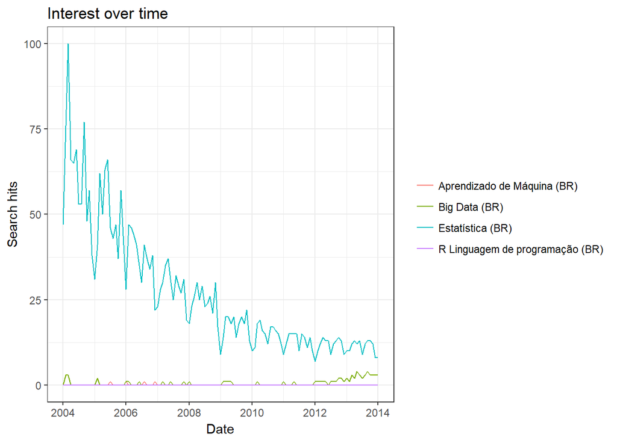

```r
plot(data_scientist)
```

É estranho observar como a popularidade do termo “Estatística” vem diminuindo tanto a medida que observamos que a popularidade do termo “Big Data” tem aumentado..

A estatística não deveria se tornar mais popular a medida que grandes bancos de dados se tornam cada vez mais populares? Fica a reflexão..

# Testando a tendência

Sejam as hipóteses:

$$H0:\text{não existe tendência}\\
H1:\text{existe tendência}$$

# Analises estatísticas

Agora que já obtemos os dados do google trends, além da visualização também podemos aplicar toda a teoria de séries temporais que já conhecemos.

o comportamento da popularidade do termo “Estatística” se apresentou de forma muito interessante, vejamos com mais detalhes o o que esses dados têm a dizer:

```r
library(dplyr)
#Selecionando apenas as observações referêntes ao termo "Estatística"
Estatistica=data_scientist$interest_over_time%>%
  filter(keyword=="Estatística")
```

## Elementos da decomposição de uma Série Temporal

Consideramos as observações ${Z_t,t = 1,...,N}$ de uma série temporal, um modelo de decomposição consiste em escrever $Z_t$ como uma soma de três componentes não-observáveis,

$$Z_t=T+S+R$$
onde:

- $T$ : Tendência
- $S$ : Sazonalidade (repetição de um fenômeno no período de tempo)
- $R$ : Aleatória (espera-se que seja um $RB$)

Para decomposição de séries temporais inicialmente vamos criar estes objetos que identificamos na base de dados:

```r
ts=ts(Estatistica$hits,freq=12)
ts_dec=decompose(ts)
```

Com os objetos em mão, vejamos os resultados da decomposição:

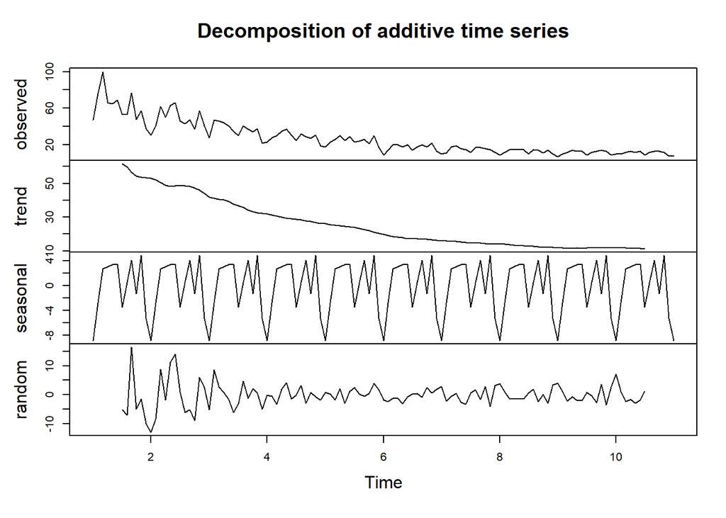

```r
plot(ts_dec)
```

Com isso somos capazes de criar modelos que possam acompanhar o comportamento da série e tendar entender suas características.

### Tendências

Inicialmente vamos supor que a componente sazonal $S_t$ não esteja presente.

Há vários métodos para estimar $T_t$, exemplos:

- ajustar uma função do tempo, como um polinômio, uma exponencial ouuma função suave de $t$;
- suavizar (ou filtrar) os valores da série ao redor de um ponto, para estimar a tendência naquele ponto
- suavizar os valores da série através de sucessivos ajustes de retas de mínimos quadrados ponderados (“lowess”)

#### Testes para tendência

Sejam as hipóteses:

$$H_0: \text{não existe tendência} \\
H_1: \text{existe tendência}$$

Para avaliar estar hipóteses temos uma série de testes disponíveis, veja:

- Teste de sequências (Wald-Wolfowitz)

```r
randtests::runs.test(ts)
```

```
##
##  Runs Test
##
## data:  ts
## statistic = -9.935, runs = 6, n1 = 58, n2 = 59, n = 117, p-value <
## 2.2e-16
## alternative hypothesis: nonrandomness
```

O teste de sequênciasforneceu uma evidência de que realmente existe uma tendência da série de dados referênte à popularidade do termo “Estatística” nas mídicas sociais do Google.

### Sazonalidade

É dificíl definir tanto do ponto de vista conceitual como estatístico o que seja sazonalidade.

Empiricamente, consideramos como sazonais os fenômenos que ocorrem regularmente de ano para ano.

#### Testes para a sazonalidade

Para avaliar a sazonaldade podemos utiizar alguem teste que avalie a hipótese nula de que todas os anos possuem funções de distribuição iguais contra a hipótese alternativa de que ao menos dois dos anos possuem funções de distribuição diferentes.

A base de dados é a seguinte:

```r
data=data.frame(cbind(serie=as.numeric(ts),mes_ano=rep(seq(1,12),11)))
kruskal.test(data=data,serie~mes_ano)
```

```
##
##  Kruskal-Wallis rank sum test
##
## data:  serie by mes_ano
## Kruskal-Wallis chi-squared = 12.021, df = 11, p-value = 0.3621
```

### Método de Amortecimento exponencial de Holt-Winters (dados com sazonalidade)

Este modelo ajuda a descobrir padrão de comportamento complexos. A previsao deste modelo é feita de acordo com a série que pode ser Sazonal Aditiva ou Sazonal Multiplicativa.

É uma adaptação do modelo de amortecimento exponencial de Holt-Winters para dados com sazonalidade. Um parâmtro será incluído nas equações e teremos um novo parâmtro que será a constante de amortecimento dos fatores sazonais

No R, considerando a série sazonal aditiva (por default do R):

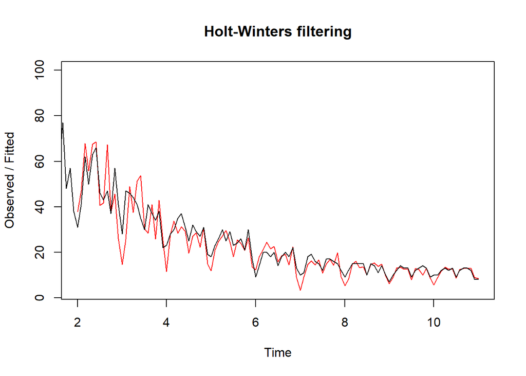

```r
ajuste_com_sazonalidade<-HoltWinters(ts)
plot(ajuste_com_sazonalidade)
```

Note que o ajuste de Holt-Winters obtem melhores resultados para valores mais próximos, pois atribui maior peso para observações mais recentes.

Com a função forecast() podemos obter previsoes do modelo, veja:

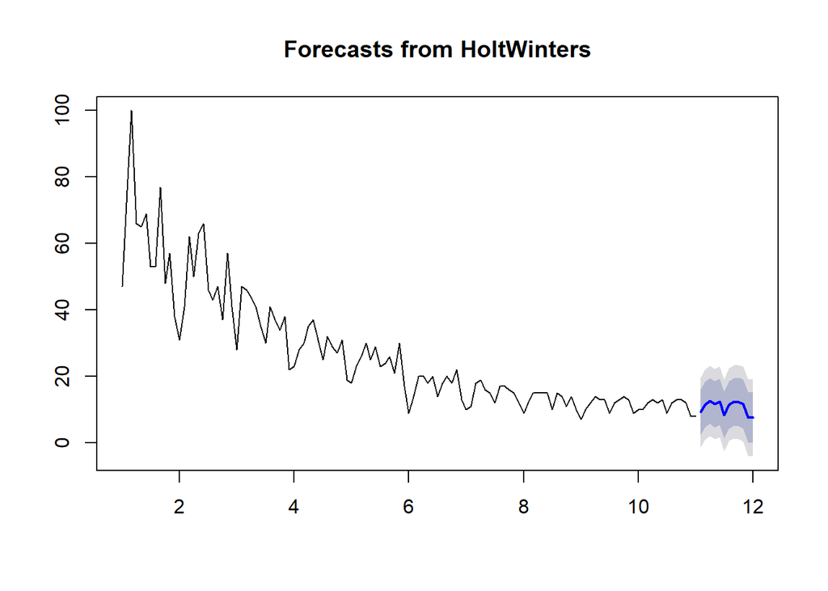

```r
library(forecast)
previsao_com_sazonalidade<-forecast(ajuste_com_sazonalidade,h = 12)
plot(previsao_com_sazonalidade)
```

# Muito a fazer

Pretendi trazer aqui uma idéia de como a combinação de alguns pacotes junto a artíficios estatísticos podem revelar insformações interessantes, esses dados são livres para qualquer pessoa e podem gerar insights poderosos para a tomada de decisão, agora com mais uma nova ferramenta na caixinha basta colocar a mão na massa!